# hw

zhi ya chen

2020-12-19

# hw1

## Question1

Graph the density histogram of the sample with the Pareto(2, 2) density superimposed for comparison.

## Answer

对题目建模可得直方图和密度函数的对比图

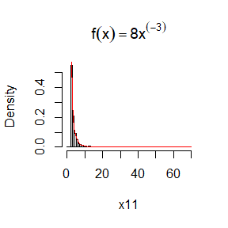

```r
u11 <- runif(500)
x11=2/sqrt(1-u11)##分布函数的反函数
hist(x11, prob = TRUE, breaks=seq(0,ceiling(max(x11)),1),main = expression(f(x)== 8*x^(-3) ) )
y11 <- seq(0,ceiling(max(x11)),1)
lines(y11, 8*y11^(-3),col = "red")
```

可见基本是直方图是基本吻合密度曲线的。

## Question2

Write a functionto generate random variates from fe, and construct the histogram density estimate of a large simulated random sample.

## Answer

基于题目意思写成的算法，和图像的对比

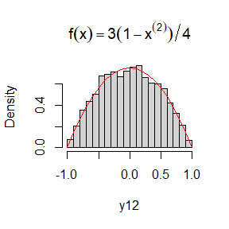

```r
y12=c()
for(i in 1:5000){
  x12=runif(3,-1,1)
  if( ( abs(x12[3])>=abs(x12[1]) )&&( abs(x12[3])>=abs(x12[2]) ) )   {y12=c(y12,x12[2])}
  else   {y12=c(y12,x12[3])}
}##生成密度函数的样本
hist(y12, prob = TRUE, breaks=seq(-1,1,0.1),main = expression(f(x)== 3*(1-x^(2))/4 ) )
z12 <- seq(-1,1,0.1)
lines(z12, 3/4*(1-z12^(2)),col = "red")
```

可见基本是直方图是基本吻合密度曲线的。

## Question3

Prove that the algorithm given in Exercise 3.9 generates variates from the density fe

## Answer

由于$U_1$，$U_2$，$U_3$是独立同分布的，所以三个的联合密度函数为$\frac{1}{8}$。

记$Y$为例题二算法得到的随机变量。故$P(Y\le s)=\iiint_{A} p(x,y)\, dx\,dy\, dz$ 其中$x$，$y$，$z$分别代表$U_1$，$U_2$，$U_3$，并且$p(x,y)=\frac{1}{8}$，$A=A_1 \cup A_2\cup A_3$。

$Y$第一种取值情况下 $A_1=\lbrace (y\le s)\cup(|y| \le |x|)\cup(|z| \le |x|) \rbrace$

同理 $Y$第二种取值情况下为$A_2$，$A_3$。 $A_2=\lbrace (x\le s)\cup(|x| \le |y|)\rbrace$ $A_3=\lbrace (x\le s)\cup(|y| \le |x|)\cup(|x| \le |z|) \rbrace$

由于三个集合互不相容，分别对三个集合求积分可得

$P(Y\le s)=\iiint_{A_1 \cup A_2\cup A_3} \frac{1}{8}\, dx\,dy\, dz$

$P(Y\le s)=(\frac{s+1}{4}-\frac{s^3+1}{12})+(\frac{s+1}{2}-\frac{s^2+1}{4})+(\frac{s^2-1}{4}-\frac{s^3+1}{6})$

化简得$P(Y\le s)=\frac{3s}{4}-\frac{s^3}{4}$易验证这个为密度函数$\frac{3(1-x^2)}{4}$的分布函数。

证毕。

## Answer

对题目计算得到反函数以后，用均匀分布来生成密度函数的样本，并画出对比图

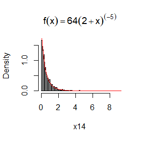

```r
u14 <- runif(1000)
x14=2/(1-u14)^(1/4)-2##分布函数的反函数
hist(x14, prob = TRUE, breaks=seq(0,ceiling(max(x14)),0.1),main = expression(f(x)== 64*(2+x)^(-5) ) )
y14 <- seq(0,ceiling(max(x11)),0.1)
lines(y14, 64*(2+y14)^(-5),col = "red")
```

两者基本符合。

# hw2

## Question1

Compute a Monte Carlo estimateand compare your estimate with the exact value of the integral.

## Answer

用模特卡洛计算积分可得

```r
a21=runif(10000, min=0, max=1/3*(pi))
b21=mean(sin(a21)) *1/(1/3*(pi))
```

通过积分计算可得

```r
g21<-function(x) {sin(x)}
c21=integrate(g21,0,1/3*(pi))$value
```

两者对比

```r
c(abs(b21-c21),abs(b21-c21)/b21)
```

```
## [1] 0.04164651 0.09086111
```

可见误差是比较小的

## Question2

Compute an empirical estimate of the percent reduction in variance using the antithetic variate. Compare the result with the theoretical value from Exercise 5.6.

## Answer

```r
#对偶法
u221=runif(5000)
a221=sum(exp(u221)+exp(1-u221) )/10000
##mc法
u222=runif(10000)
a222=mean(exp(u222))
##积分计算
g22<-function(x) {exp(x)}
e22=integrate(g22,0,1)$value
c(a221,a222,e22)
```

```
## [1] 1.718192 1.717784 1.718282
```

计算方差

```r
b221=var( (exp(u221)+exp(1-u221))/2 )
b222=var(exp(u222))
c(b222-b221,b221/b222)
```

```
## [1] 0.23661646 0.01600398
```

可见对偶法的方差比mc小了特别多

## Question3

ﬁnd the value c∗ that minimizes the variance of the estimatorue in equation (5.11). (c∗ will be a function of the variances and the covariance of the estimators.)

## Answer

化简$Var( c\theta_1+(1-c)\theta_2)=Var(\theta_2)+2cCov(\theta_1-\theta_2,\theta_2)+c^2Var(\theta_1-\theta_2)$

对$c$进行配方，可得到 $Var(\theta_1-\theta_2)(c+\frac{Cov(\theta_1-\theta_2,\theta_2)}{Var(\theta_1-\theta_2)})^2+ Var(\theta_2)-(\frac{Cov(\theta_1-\theta_2,\theta_2)}{Var(\theta_1-\theta_2)})^2$

故可得，当$c=-\frac{Cov(\theta_1-\theta_2,\theta_2)}{Var(\theta_1-\theta_2)}$时，方差$Var( c\theta_1+(1-c)\theta_2)$达到最小值。

#hw4

## Question1

Estimate the power of the skewness test of normality against symmetric Beta(α, α) distributions and comment on the results. Are the results different for heavy-tailed symmetric alternatives ?

## Answer

```r
##定义拒绝域的生成函数b1
f411<-function(m){
mean411=mean(m)
a411=mean( (m-mean411)^3 )
a412=mean( (m-mean411)^2 )
return( a411/a412^(1.5) )
}
##五个不同的取样次数
n411=c(100,200,500,1000,2000)
cv411 <- qnorm(.975, 0, sqrt(6*(n411-2) / ((n411+1)*(n411+3))))
f412<-function(beta){
k411=numeric(length(n411))
for (i in 1:length(n411)){
  k412=numeric(10000)
  for(j in 1:10000){
    b411=rbeta(n411[i],beta,beta)
    k412[j]=as.integer( abs(f411(b411)) >= cv411[i] )
  }
  k411[i]=mean(k412)
}
return(k411)
}
###选择了五个不同参数
cbind(f412(1),f412(5),f412(10),f412(100),f412(1000))
```

```
##        [,1]   [,2]   [,3]   [,4]   [,5]
## [1,] 0.0017 0.0088 0.0217 0.0485 0.0486
## [2,] 0.0013 0.0058 0.0164 0.0462 0.0536
## [3,] 0.0012 0.0060 0.0188 0.0468 0.0539
## [4,] 0.0017 0.0058 0.0175 0.0487 0.0472
## [5,] 0.0005 0.0070 0.0171 0.0452 0.0490
```

选择了五个不同的参数$1,5,10,100,1000$和五个不同取样数量$100,200,500,1000,2000$。根据b1的计算公式和对称beta分布的性质可知,随着beta的参数增大，随机数离0.5的偏离越小，这也是让$\beta_1$更接近0，所以p值会随着参数的大幅度增大而变大，进而在0.05水平下接受原假设。

```r
##讲随机数换成t分布
f413<-function(beta){
  k411=numeric(length(n411))
  for (i in 1:length(n411)){
    k412=numeric(10000)
    for(j in 1:10000){
      b411=rt(n411[i],beta)
      k412[j]=as.integer( abs(f411(b411)) >= cv411[i] )
    }
    k411[i]=mean(k412)
  }
  return(k411)
}
###选择了五个不同参数
cbind(f413(1),f413(5),f413(10),f413(100),f413(1000))
```

```
##        [,1]   [,2]   [,3]   [,4]   [,5]
## [1,] 0.9522 0.4075 0.1910 0.0602 0.0498
## [2,] 0.9762 0.4804 0.2237 0.0621 0.0535
## [3,] 0.9912 0.5658 0.2596 0.0628 0.0530
## [4,] 0.9949 0.6236 0.2784 0.0628 0.0500
## [5,] 0.9976 0.6656 0.3031 0.0618 0.0531
```

由结果可知，对t分布当参数较小的时候，p值是特别大的，随着参数自由度$df$逐渐变大，t分布趋于正态，p值开始下降，在$df=1000$的时候会生成在0.05水平下拒绝原假设的随机数。

## Question2

Refer to Example 6.16. Repeat the simulation, but also compute the F test of equal variance, at significance level ˆα = 0.055. Compare the power of the Count Five test and F test for small, medium, and large sample sizes. (Recall that the F test is not applicable for non-normal distributions.)

## Answer

```r
##定义Count Five函数
f421=function(x421, y421) {
  X421=x421 - mean(x421)
  Y421=y421 - mean(y421)
  a421<- sum(X421 > max(Y421)) + sum(X421 < min(Y421))
  b421<- sum(Y421 > max(X421)) + sum(Y421 < min(X421))
  return(as.integer(max(c(a421, b421)) > 5))
}
f422=function(x422){
  power1<-replicate(1000, expr={
    x4 <- rnorm(x422, 0, 1)
    y4 <- rnorm(x422, 0, 1.5)
    a411=var.test(x4, y4, ratio = 1,
                  alternative = c("two.sided", "less", "greater"),
                  conf.level = 0.95)$p.value
    c(a411,f421(x4, y4))
  })
  c(mean(power1[1,]),mean(power1[2,]))
}
##第一行是F检验的，第二行是five函数
cbind(f422(6),f422(8),f422(10),f422(20),f422(40),f422(60),f422(80),f422(100),f422(120),f422(140))
```

```
##           [,1]      [,2]      [,3]     [,4]       [,5]       [,6]       [,7]
## [1,] 0.3961704 0.3356843 0.3389309 0.195788 0.07700227 0.02810218 0.01041868
## [2,] 0.0120000 0.0630000 0.1070000 0.327000 0.56000000 0.71600000 0.78400000
##             [,8]        [,9]       [,10]
## [1,] 0.006352869 0.002420483 0.001069522
## [2,] 0.839000000 0.887000000 0.914000000
```

由结果可见基本上F检验是随着随机数数量增大而p值减小，five函数则相反。

## Question3

Repeat Examples 6.8 and 6.10 for Mardia’s multivariate skewness test.

## Answer

对于一维情形的正态分布极大似然估计，可得$\hat{\mu}=\overline{X},\hat{\sigma}^2=\frac{1}{n}\sum_i(X_i-\hat{\mu})^2$则可依据这个化简Mardia检验

```r
##先重复6.8
##定义好d的求值函数
f431<-function(m){
  mean431=mean(m)
  sigma431=sum( (m-mean431)^2 )/length(m)
  a411=numeric(0)
  a431=t(t( (m-mean431)^3 ))%*% t( (m-mean431)^3 )
  a411=sum(a431)/(length(m)^2*sigma431^3)
  return( a411 )
}
##给定取样次数
n431=c(50,100,200,400,700,1000)
b431=(1/n431)*6*qchisq(0.95,1)
f432=function(beta){
  k431=numeric(length(n431))
  for (i in 1:length(n431)){
    k432=numeric(1000)
    for(j in 1:1000){
      c431=rbeta(n431[i],beta,beta)
      k432[j]=as.integer( abs(f431(c431)) >= b431[i] )
    }
    k431[i]=mean(k432)
  }
  return(k431)
}

cbind(f432(1),f432(5),f432(10),f432(100),f432(1000))
```

```
##       [,1]  [,2]  [,3]  [,4]  [,5]
## [1,] 0.005 0.007 0.019 0.037 0.031
## [2,] 0.000 0.004 0.020 0.040 0.043
## [3,] 0.001 0.008 0.016 0.040 0.064
## [4,] 0.001 0.013 0.018 0.042 0.041
## [5,] 0.000 0.004 0.028 0.037 0.051
## [6,] 0.001 0.007 0.020 0.047 0.048
```

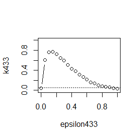

```r
##复现6.10
n433=30
m433=2500
epsilon433=seq(0, 1, 0.05)
k433=numeric(length(epsilon433))
##使用b31为定值参数
for (j in 1:length(epsilon433)) {
  d433=epsilon433[j]
  a433<-numeric(m433)
  for (i in 1:m433) {
    sigma4=sample(c(1, 10), replace = TRUE,size = n433, prob = c(1-d433, d433))
    x=rnorm(n433, 0, sigma4)
    a433[i]=as.integer( abs( f431(x) ) >= (6*qchisq(0.95,1)/n433) )
  }
  k433[j]=mean(a433)
}
#plot power vs epsilon
plot(epsilon433, k433, type = "b",
     xlab = bquote(epsilon433), ylim = c(0,1))
abline(h = 0.05, lty = 3)
```

可见随着$\epsilon$靠近0和1，随着函数越接近正态分布的函数，p值趋于0.05

## Question4

If we obtain the powers for two methods under a particular simulation setting with 10,000 experiments: say, 0.651 for one method and 0.676 for another method. Can we say the powers are different at 0.05 level? 1.What is the corresponding hypothesis test problem? 2.What test should we use? Z-test, two-sample t-test, paired-t test or McNemar test? 3.What information is needed to test your hypothesis?

## Answer

1.对立假设如下 $H_0$:在重复次数为10000次，随机样本相同的情况下，方法一的P值和方法二的P值在0.05水平下是相等的 $H_1$:在重复次数为10000次，随机样本相同的情况下，方法一的P值和方法二的P值在0.05水平下是不相等的

2.Z检验要求方差已知。两个t检验都要求正态分布或者渐近正态的性质。但是因为方法的不同不能保证，选择McNemar test。

3.需要生成同一批10000个样本，每个样本计算一次是拒绝(1)还是接受原假设(0)，然后用$\frac{(b-c)^2}{b+c}$来对比0.05水平下的卡方分布。

#hw6

## Question1

Implement a permutation test for equal variance based on the maximum number of extreme points that applies when sample sizes are not necessarily equal.

## Answer

```r
##两个不同的样本量
x61=rnorm(20, 1, sd = 2)
y61=rnorm(15, 1, sd = 2)
##使用count5比较
count5test6 <- function(x, y) {
  X <- x - mean(x)
  Y <- y - mean(y)
  outx <- sum(X > max(Y)) + sum(X < min(Y))
  outy <- sum(Y > max(X)) + sum(Y < min(X))
  return(as.integer(max(c(outx, outy)) > 5))
}
R61 = 999;
z61 = c(x61, y61)
K61 = 1:35
set.seed(11111)
rep61 = numeric(R61)
t610 = count5test6(x61, y61)
for (i in 1:R61) {
  k61 =sample(K61, size = length(x61), replace = FALSE)
  x61 = z61[k61]
  y61 = z61[-k61]
  rep61[i] = count5test6(x61, y61)
}
p61=mean(c(t610,rep61))
round(c(p61),3)
```

```
## [1] 0.064
```

故在置信水平0.05的情况下认为$x_1,y_1$的分布是相同的，尽管两者的样本量不一样。

## Question2

Design experiments for evaluating the performance of the NN, energy, and ball methods in various situations. 1.Unequal variances and equal expectations 2.Unequal variances and unequal expectations 3.Non-normal distributions: t distribution with 1 df (heavy-tailed distribution), bimodel distribution (mixture of two normal distributions) 4.Unbalanced samples (say, 1 case versus 10 controls)

## Answer

```r
library("Ball")
library("energy")
library(boot)
library(RANN)
Tn62 = function(z, ix, sizes,k) {
  n1 = sizes[1]
  n2 = sizes[2]
  n = n1 + n2
  if(is.vector(z)) {z = data.frame(z,0)}
  z = z[ix, ]
  NN = nn2(data=z, k=k+1)
  block1 = NN$nn.idx[1:n1,-1]
  block2 = NN$nn.idx[(n1+1):n,-1]
  i1 = sum(block1 < n1 + .5)
  i2 = sum(block2 > n1+.5)
  return((i1 + i2) / (k * n))
}
eqdist.nn6 <- function(z,sizes,k){
  boot.obj <- boot(data=z,statistic=Tn62,R=999,
                   sim = "permutation", sizes = sizes,k=k)
  ts = c(boot.obj$t0,boot.obj$t)
  p.value =mean(ts>=ts[1])
  list(statistic=ts[1],p.value=p.value)
}
##下面分别对不同情况计算p值
##情况一
m6 = 300##迭代次数
set.seed(10001)
n61 = n62 = 50##样本数
k6=3; n6 <- n61+n62; N6 = c(n61,n62)
p6=1#矩阵列数
##方差和均值
sd61 =1
sd62=2
mu61=mu62=0
R6=999##随机次数
p.values61 <- matrix(NA,m6,3)
for(i in 1:m6){
  x6 = matrix(rnorm(n61,mu61,sd61),ncol=p6);
  y6 = cbind(rnorm(n62,mu62,sd62));
  z6 = rbind(x6,y6)
  p.values61[i,1] = eqdist.nn6(z6,N6,k6)$p.value
  p.values61[i,2] = eqdist.etest(z6,sizes=N6,R=R6)$p.value
  p.values61[i,3] = bd.test(x=x6,y=y6,num.permutations=999,seed=i*12345)$p.value
}
alpha61 = 0.05;
pow61 = colMeans(p.values61<alpha61)
round(pow61,5)
```

```
## [1] 0.61333 0.83000 0.95667
```

从拒绝原假设的比例上来看，在情况一的条件下可见NN法的效率是最差的，bdtest的效果最好

```r
##情况二
m6 = 300##迭代次数
R6=999##随机次数
set.seed(10002)
n61 = n62 = 50##样本数
n6 = n61+n62; N6 = c(n61,n62)
##不同的方差和均值
sd61 =1;sd62=1.5;mu61=1;mu62=0
p.values62 <- matrix(NA,m6,3)
for(i in 1:m6){
  x6 = matrix(rnorm(n61,mu61,sd61),ncol=p6)
  y6 = cbind(rnorm(n62,mu62,sd62));
  z6 = rbind(x6,y6)
  p.values62[i,1] = eqdist.nn6(z6,N6,k6)$p.value
  p.values62[i,2] = eqdist.etest(z6,sizes=N6,R=999)$p.value
  p.values62[i,3] = bd.test(x=x6,y=y6,num.permutations=999,seed=i*12345)$p.value
}
alpha61 = 0.05;
pow62 = colMeans(p.values62<alpha61)
print(pow62)
```

```
## [1] 0.6833333 0.9900000 0.9833333
```

在这种情况下，可见energy法最佳，而且和bd法相差无几，效果都接近了0.99

```r
##情况三
m6 = 300##迭代次数
R6=999##随机次数
set.seed(11113)
n61 = n62 = 50##样本数
n6 = n61+n62; N6 = c(n61,n62)
p.values63 <- matrix(NA,m6,3)
for(i in 1:m6){
  ##先考虑t分布
  x6 = matrix(rt(n61,1),ncol=p6);
  ##将混合正态的均值也设成0
  y6 = cbind(0.3*rnorm(n62,0,1)+0.7*rnorm(n62,0,2))
  z6 = rbind(x6,y6)
  p.values63[i,1] = eqdist.nn6(z6,N6,k6)$p.value
  p.values63[i,2] = eqdist.etest(z6,sizes=N6,R=R6)$p.value
  p.values63[i,3] = bd.test(x=x6,y=y6,num.permutations=999,seed=i*12345)$p.value
}
alpha61 = 0.05;
pow63 = colMeans(p.values63<alpha61)
print(pow63)
```

```
## [1] 0.2766667 0.4133333 0.2566667
```

可以发现在分正态分布的情况下，反而是第二种energy的方法更好

```r
##情况四
m6 = 300##迭代次数
R6=999##随机次数
set.seed(10002)
n61=50;n62=30##不同的样本数
n6 = n61+n62; N6 = c(n61,n62)
##不同的方差和相同的均值
sd61 =1;sd62=1;mu61=1;mu62=0
p.values64<- matrix(NA,m6,3)
for(i in 1:m6){
  x6 = matrix(rnorm(n61,mu61,sd61),ncol=p6)
  y6 = cbind(rnorm(n62,mu62,sd62));
  z6 = rbind(x6,y6)
  p.values64[i,1] = eqdist.nn6(z6,N6,k6)$p.value
  p.values64[i,2] = eqdist.etest(z6,sizes=N6,R=R6)$p.value
  p.values64[i,3] = bd.test(x=x6,y=y6,num.permutations=999,seed=i*12345)$p.value
}
alpha61 = 0.05;
pow64 = colMeans(p.values64<alpha61)
print(pow64)
```

```
## [1] 0.6333333 0.9833333 0.9366667
```

```r
##不同的方差和相同的均值
sd61 =1;sd62=2;mu61=0;mu62=0
p.values65<- matrix(NA,m6,3)
for(i in 1:m6){
  x6 = matrix(rnorm(n61,mu61,sd61),ncol=p6)
  y6 = cbind(rnorm(n62,mu62,sd62));
  z6 = rbind(x6,y6)
  p.values65[i,1] = eqdist.nn6(z6,N6,k6)$p.value
  p.values65[i,2] = eqdist.etest(z6,sizes=N6,R=R6)$p.value
  p.values65[i,3] = bd.test(x=x6,y=y6,num.permutations=999,seed=i*12345)$p.value
}
alpha61 = 0.05;
pow65 = colMeans(p.values65<alpha61)
print(pow65)
```

```
## [1] 0.5433333 0.6666667 0.8066667
```

#hw9

## Question1

Write an Rcpp function for Exercise 9.4

## Answer

```r
library(Rcpp)
##如下，random为生成正态随机数的cpp函数，chain为生成随机游走的函数
sourceCpp(code='
#include <Rcpp.h>
using namespace Rcpp;

//[[Rcpp::export]]
  NumericVector random(double sigma, int n) {
      NumericVector runif(n);
      for(int i = 0; i < n; i++) {
        double U, V,Z;
        U = rand()/ (RAND_MAX + 1.0);
        V = rand()/ (RAND_MAX + 1.0);
        Z=sqrt(-2.0 * log(U))* sin(2.0 * 3.141592654 * V);
        runif[i] = sigma*Z;

      }
      return runif;
  }

//[[Rcpp::export]]
    NumericVector chain(double sig, int n1){
    NumericVector rw(n1+1),x1(n1);
    rw[0]=exp(-1)/2;
    x1=random(sig,n1);
    int k1;
    double y1;
    k1=0;
    for(int i = 1; i < n1; i++) {
      y1=random(sig,1)[0]+rw[i-1];
        if (x1[i-1] <= (exp(-abs(y1))/exp(-abs( rw[i-1] ))) )
            {rw[i]=y1;}
        else {
            rw[i]=rw[i-1];
            k1=k1 + 1;
        }
    }
    rw[n1]=k1;
    return(rw);
  }
')
##由于c语言画图的可视化比较复杂，采用R语言本身的画图来比较链的区别
N91=1000
sigma91=c(0.1,0.7, 1,4)
rw911=chain(sigma91[1], N91)
rw912=chain(sigma91[2], N91)
rw913=chain(sigma91[3], N91)
rw914=chain(sigma91[4], N91)
##对比拒绝的比例并画图比较数据
c(rw911[(N91+1)], rw912[(N91+1)], rw913[(N91+1)], rw914[(N91+1)])/N91
```

```
## [1] 0.000 0.139 0.179 0.339
```

## Question2

Compare the corresponding generated random numbers with those by the R function you wrote before using the function “qqplot”.

## Answer

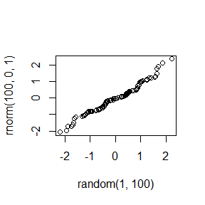

```r
library(Rcpp)
qqplot(random(1,100),rnorm(100,0,1))
```

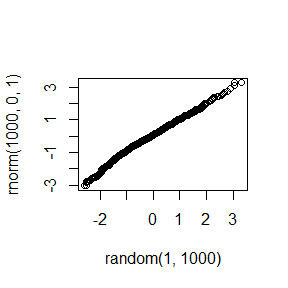

```r
qqplot(random(1,1000),rnorm(1000,0,1))
```

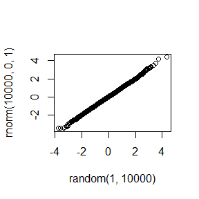

```r
qqplot(random(1,10000),rnorm(10000,0,1))
```

可见随着样本数量增大，图象趋于直线，即两个样本的分布几乎相同。

## Question3

Campare the computation time of the two functions with the function “microbenchmark”.

## Answer

```r
library(microbenchmark)
x93=1000
a93=microbenchmark(rnorm=runif(x93,0,2),randomcpp=random(2,x93))
print(summary(a93)[,c(1,3,5,6)])
```

```
##        expr   lq median     uq
## 1     rnorm 29.4  30.20  31.35
## 2 randomcpp 95.3  97.75 116.90
```

由结果可知，可以发现编写的C程序花费了更运算时间，所以还需要进一步优化。